# Digital media supporting literacy learning in children with communicative and cognitive disabilities

## Training time

The participants were instructed to train for a total of 18 hours (36 sessions for 30 minutes, three days a week for a 12-week period). The teachers were instructed to adapt the length of the training sessions after the need of the student. That is, if the student could not sit for a full 30 minute session the teacher was encouraged to have shorter sessions but more often than three times a week. On average the participants trained for 384.932 (*sd* =194.118) minutes (6.416 (*sd* =3.235) hours). There was no difference on training time between the three intervention groups (*H*(2) = 0.572, *p* =.751 ).

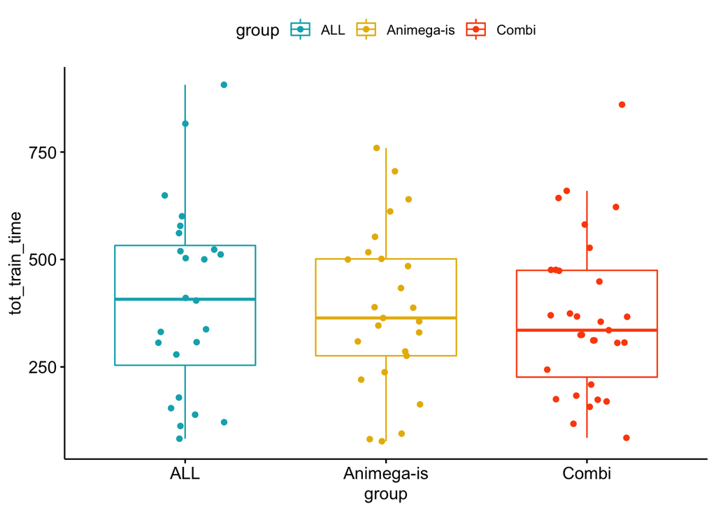

## Phonological awareness

### Hypothesis 1a: Training phonemic reading strategies improves phonological awareness.

There was almost a significant interaction between time and the intervention on phonemic reading, the group training phonemic strategies improved more than the comparison group ($\hat{\beta} = 0.01$, 95% CI $[0.00, 0.02]$, $t(362.23) = 1.66$, $p = .097$).

### Hypothesis 1b: Training comprehension-based reading strategies improves phonological awareness.

There was no significant interaction between time and intervention for the comprehension-based reading strategy on PA ($\hat{\beta} = 0.00$, 95% CI $[0.00, 0.01]$, $t(362.87) = 1.11$, $p = .266$).

### Hypothesis 3: The combined training is more effective than either intervention on its own.

There was a significant interaction between the combined group and the other two intervention groups, ($\hat{\beta} = 0.01$, 95% CI $[0.00, 0.02]$, $t(361.67) = 2.76$, $p = .006$), the combined training improved PA over time more than the other two intervention groups.

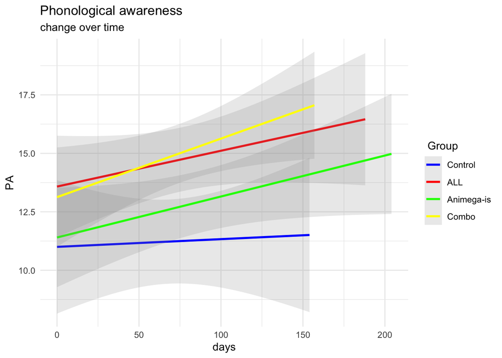